# Introdução ao ambiente R

Aula 01 · Introdução à Linguagem R

Diogo B. Provete

PPG em Ecologia e Conservação · UFMS

# A disciplina

## Programa do curso

1. Introdução ao R
2. Organização e curadoria dos dados
3. Importação e manipulação de dados
4. Controle de versão (git e GitHub)
5. Análise — modelos lineares simples
6. Gráficos com `ggplot2`
7. Rudimentos de programação
8. Reprodutibilidade em pesquisa (Markdown e Quarto)

## Avaliação

Atividades diárias, feitas por vocês:

- **P1** — os *scripts* que vocês produzirem ao longo da semana
- **P2** — trabalho final em Markdown/Quarto

Repare que as duas notas são **código que roda**. Não há prova escrita.

## Cronograma — segunda

**Manhã**

- Ambientação no R e no RStudio
- Tipos de objetos
- Como obter ajuda
- Como escrever e organizar um script

**Tarde**

- Organização dos dados no seu computador
- Boas práticas e curadoria de dados

## Cronograma — terça

**Manhã**

- Controle de versão com git e GitHub

**Tarde**

- Manipulação de dados e a estratégia *split-apply-combine*: o `tidyverse`
- *Subsetting*, `summarize()`, `group_by()`, o operador *pipe*

## Cronograma — quarta

**Manhã**

- Análises simples com modelos lineares
- Gráficos com `ggplot2`

**Tarde**

- Exercícios com gráficos
- Análises com `tidyverse` e modelos lineares
- Rudimentos de programação

## Cronograma — quinta e sexta

**Quinta, manhã**

- Reprodutibilidade em pesquisa: Markdown, knitr e Quarto
- Como organizar um documento Quarto

**Quinta, tarde**

- Exercícios com Quarto

**Sexta, manhã**

- Tira-dúvidas

## Onde ficam os materiais

**Este site** — slides, scripts e dados de todas as aulas:

[provetelab.org/intro-r](https://provetelab.org/intro-r/)

**Moodle da UFMS** — quizzes, entregas e avaliações da turma:

ava.ufms.br

A chave de inscrição do Moodle eu passo em aula.

# Por que programar

## Por que uma linguagem, e não um menu

- **Controle do que se quer fazer** — você conhece todos os passos da análise
- O preço: é preciso **aprender uma linguagem**
- **Gratuito e aberto**, amplamente usado por biólogos — análises novas aparecem primeiro em R

O argumento decisivo aparece na quinta-feira: análise feita clicando em menu não pode ser auditada nem repetida. O script é a receita.

## O que dizem por aí

> “For students entering my lab, I place a premium on **quantitative skills**, intellectual creativity, hard work, and independence.”

> “What kinds of skills do you need for success in community ecology? You should invest the time in learning a **programming/statistical language**… R is the language that I recommend… there is no better (or more enjoyable) way to learn about statistics and ecological theory than by programming.”

Nicholas J. Gotelli, University of Vermont — [Information for Prospective Graduate Students](https://www.uvm.edu/~ngotelli/GradAdvice.html)

# Instalando

## R e RStudio são duas coisas

- **R** é a linguagem e o motor — r-project.org
- **RStudio** é o ambiente de trabalho (IDE) que roda por cima — [posit.co/download/rstudio-desktop](https://posit.co/download/rstudio-desktop/)

Instale **nessa ordem**: primeiro o R, depois o RStudio.

A empresa que faz o RStudio mudou de nome para **Posit** em 2022. Você vai encontrar os dois nomes na internet — é a mesma coisa.

## Fichas de referência

Resumos de uma ou duas páginas, por pacote. Vale imprimir as do `dplyr` e do `ggplot2` já na segunda-feira.

[opensource.posit.co/resources/cheatsheets](https://opensource.posit.co/resources/cheatsheets/)

Há versões em português de algumas delas, feitas pela comunidade.

## Estão dentro do RStudio também

**Help → Cheat Sheets** — as principais já vêm instaladas.

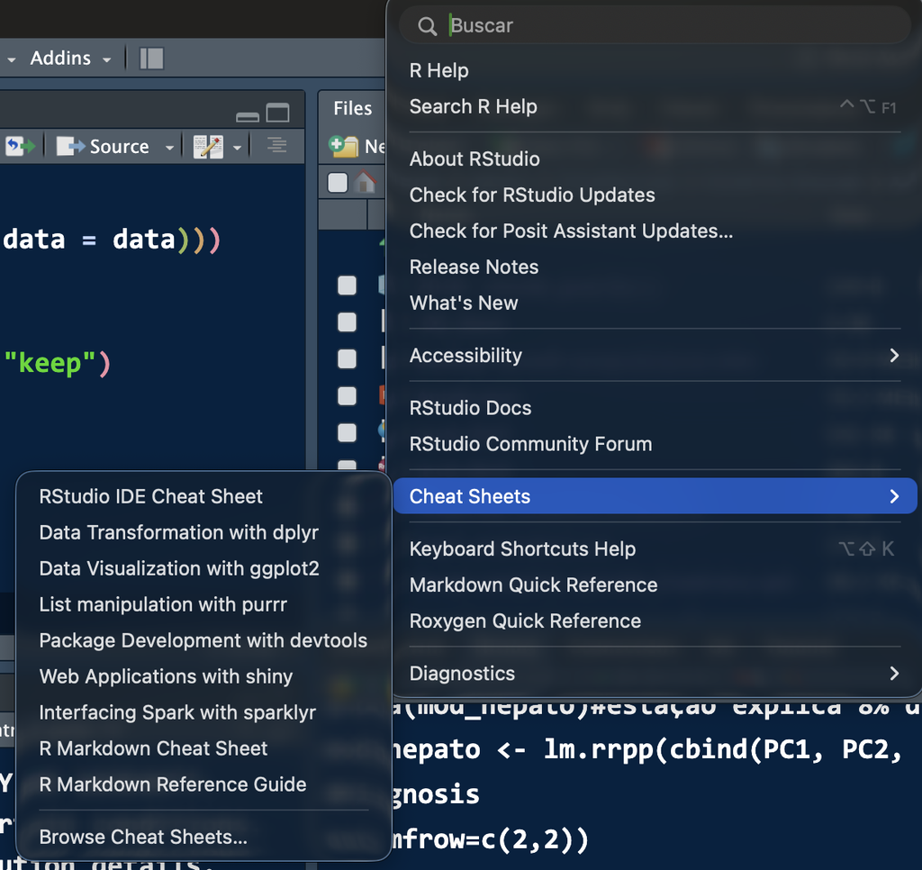

## Enquanto instala…

Dá para rodar R no navegador, sem instalar nada:

- jdoodle.com/execute-r-online
- [Posit Cloud](https://posit.cloud) — o RStudio inteiro no navegador, com conta gratuita

Serve para a primeira hora e para emergências. Não serve para o curso: a partir de amanhã vocês precisam dos arquivos na própria máquina.

## Onde procurar ajuda depois

- **Manuais e tutoriais** do CRAN — cran.r-project.org/other-docs.html
- **CRAN Task Views** — como navegar entre 20 mil pacotes por área temática: [cran.r-project.org/web/views](https://cran.r-project.org/web/views/)
- **Bioconductor** — pacotes de bioinformática, fora do CRAN
- Listas **R-SIG-XXX** por tema, e a lista brasileira **R-Br**

# O ambiente de trabalho

## Os quatro painéis do RStudio

[output not shown]

A regra do curso: **escreva no Source, não no Console.** O console esquece; o script fica.

## Os quatro painéis, de verdade

O seu vai estar vazio — e claro em vez de escuro, até mexerem em *Tools → Global Options → Appearance*.

[figure not shown]

## Comece pelo Projeto

**File → New Project…** e escolha:

- **New Directory** — projeto novo, pasta nova
- **Existing Directory** — você já tem a pasta
- **Version Control** — clonar um repositório do GitHub (terça-feira)

Por que isso importa tanto que abre o curso: o Projeto define o diretório de trabalho sozinho, e o script deixa de depender de onde a pasta está. Voltamos nisso à tarde, com `here()`.

## A janela que abre

**Version Control** é como vocês vão clonar o repositório da disciplina na terça.

[figure not shown]

## Trocando de projeto

O canto superior **direito** mostra o projeto aberto — e lista os outros. Cada um abre com sessão, histórico e arquivos próprios.

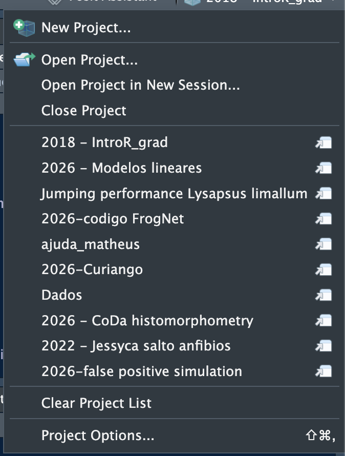

## Duas facilidades que economizam horas

- **Tab completion** — comece a digitar e aperte `Tab`. Funciona para funções, argumentos, nomes de objetos e caminhos de arquivo
- **Snippets** — atalhos que expandem para blocos de código. Digite `fun` e `Tab` para o esqueleto de uma função

[Documentação dos snippets](https://docs.posit.co/ide/user/ide/guide/productivity/snippets.html)

# A linguagem

## Seguindo no livro

Esta parte acompanha o capítulo 4 de [Análises Ecológicas no R](https://analises-ecologicas.com/cap4.html#funcionamento-da-linguagem-r).

Leiam em casa o que não der tempo de ver aqui.

## O R como calculadora

```r
2 + 3
10 / 4
2^10
sqrt(144)
5 %% 2      # resto da divisão
5 %/% 2     # divisão inteira
```

O prompt `>` espera um comando novo. O prompt `+` significa que o R está esperando você **terminar** o comando anterior — quase sempre um parêntese ou uma aspa que faltou fechar.

## Atribuir é guardar

```r
a <- 1
b <- c(1, 2, 3, 4, 5)
minha.media <- mean(b)
```

- Use `<-`, não `=`. Os dois funcionam, mas `<-` é a convenção e evita confusão com os argumentos de função
- Atalho no RStudio: `Alt` + `-` (Windows/Linux) ou `Option` + `-` (Mac)
- O objeto aparece no painel **Environment** assim que é criado

## Tipos de objeto

A organização é mais simples do que parece — são duas perguntas: **quantas dimensões?** e **todos os elementos do mesmo tipo?**

|  | Homogêneo | Heterogêneo |
| --- | --- | --- |
| **1 dimensão** | vetor | **lista** |
| **2 dimensões** | matriz | **data frame** |
| **n dimensões** | array | — |

O **data frame** é o formato dos seus dados de campo: cada coluna pode ser de um tipo diferente. É com ele que vocês vão trabalhar a semana inteira.

## Os tipos dentro de um vetor

[figure not shown]

Estrutura adaptada de [Advanced R](https://adv-r.hadley.nz/vectors-chap.html), de Hadley Wickham.

## Coerção: o R nunca reclama

Um vetor atômico só guarda **um** tipo. Se você misturar, o R converte tudo para o tipo mais permissivo — **em silêncio**.

```r
c(1, 2, "três")
```

```
#> "1"  "2"  "três"        <- viraram texto!
```

```r
c(TRUE, FALSE, 1)
```

```
#> 1  0  1                 <- viraram número
```

É por isso que uma planilha com `"sem dados"` no meio de uma coluna numérica transforma a coluna inteira em texto. Guardem isso para a aula da tarde.

## O arquivo de ajuda

```r
?mean            # ajuda de uma função que você sabe o nome
help(mean)       # o mesmo
??regression     # procura por assunto
```

**O que ler, em ordem de utilidade:**

1. **Usage** — a assinatura da função e os valores padrão
2. **Arguments** — o que cada argumento faz
3. **Examples**, no fim — quase sempre a parte mais útil

## Quando a ajuda não basta

- rseek.org — busca restrita ao universo R
- [Stack Overflow](https://stackoverflow.com/questions/tagged/r) — dúvidas de código
- [Cross Validated](https://stats.stackexchange.com) — dúvidas de estatística

Na sexta-feira falamos de como usar LLMs para isso — e do que conferir antes de acreditar na resposta.

## Instalando e carregando pacotes

```r
install.packages("vegan")   # uma vez só, na vida da máquina
library(vegan)              # toda vez que abrir o R
data(BCI)                   # carrega um conjunto de dados do pacote
```

- `install.packages()` **baixa**; `library()` **carrega**
- `install.packages()` nunca vai dentro de um script que você compartilha — ele mexe na máquina de quem rodar
- Pacotes vão **todos no começo** do script

# Entrando e saindo

## Importando dados

```r
dados <- read.table("dados/brutos/anuros.txt", header = TRUE)
dados <- read.csv("dados/brutos/anuros.csv")
```

Existe também `read.table(file.choose())`, que abre uma janela para você escolher o arquivo. **Evitem.**

Um caminho escrito no script roda de novo sozinho. Uma janela exige que alguém esteja ali para clicar — e ninguém sabe o que foi clicado da última vez.

## Conferindo o que entrou

Antes de qualquer análise, sempre estes quatro:

```r
head(dados)      # as primeiras linhas
str(dados)       # a estrutura: tipo de cada coluna
dim(dados)       # quantas linhas e colunas
summary(dados)   # resumo por coluna
```

O `str()` é o mais importante: é onde você descobre que a coluna que deveria ser numérica entrou como texto.

## Exportando

```r
write.csv(objeto, "dados/processados/resultado.csv", row.names = FALSE)
write.table(objeto, "resultado.txt", sep = "\t", quote = FALSE)
```

- Escreva em `.csv` ou `.txt` — formatos abertos
- `row.names = FALSE` evita aquela primeira coluna de números sem nome
- O que sai do script vai para `dados/processados/`, nunca por cima do bruto

## Quais funções você aprendeu hoje?

Anote, com uma frase cada, o que faz cada função nova desta manhã:

```r
c()   mean()   sqrt()   head()   str()   dim()   summary()
library()   install.packages()   read.csv()   write.csv()   ?
```

Esse caderninho vale mais que o slide. E na sexta-feira ele vira o seu próprio resumo da disciplina.